# Lecture 9：階層ベイズによる個人の選択と需要の推定

計量経済学II

Kei Ikegami

## 今日の問い

同じ顧客の次の選択を、個人の履歴を使って予測できるか。

- 第7回のイヤホンCBCへ戻る。
- 第8回の情報共有を、離散選択の尤度と組み合わせる。
- 推定した事後分布は次回のクーポン施策に使う。

## 何を固定し、何を推定するか

$$u_{ijt}=x_{ijt}'\beta-\exp(\theta_i)p_{ijt}+\varepsilon_{ijt}$$

- 価格は千円、外部選択肢あり。
- 属性係数 $\beta=(.5,.8,.3)$ は既知に固定。
- $\theta_i\sim N(\mu,\tau^2)$ の個人係数と母集団を推定。

## 300人、推定8問・検証8問

同じ個人には同じ真の係数。課題の属性・価格と選択誤差は新しく引く。

| sample | N | tasks |
| --- | --- | --- |
| 推定 | 300 | 8 |
| 検証 | 300 | 8 |

## 個人の尤度

$$L_i(\theta_i)=\prod_t P_{i,y_{it},t}(\theta_i)$$

一人の複数回答を、同じ係数で説明する。

個人の回答が少なくても、母集団の分布を他の人から学べる。

## 事後分布

$$p(\theta,\mu,\tau^2\mid D)\propto\prod_i L_i(\theta_i)\phi(\theta_i;\mu,\tau^2)p(\mu)p(\tau^2)$$

本人の尤度 × 母集団の分布 × 母集団パラメータの事前。

## MetropolisとGibbs

- 個人係数は近くに候補を作り、尤度と母集団密度で採用を決める。
- 母集団平均と分散は条件付き分布から引く。
- 最大値へ収束させるのではなく、事後分布を探索する。

## 母集団の真値と事後平均

| parameter | truth | posterior_mean | lower | upper |
| --- | --- | --- | --- | --- |
| mu | -2.3 | -2.333 | -2.448 | -2.228 |
| tau | 0.6 | 0.611 | 0.506 | 0.728 |

## 個人の区間は広い

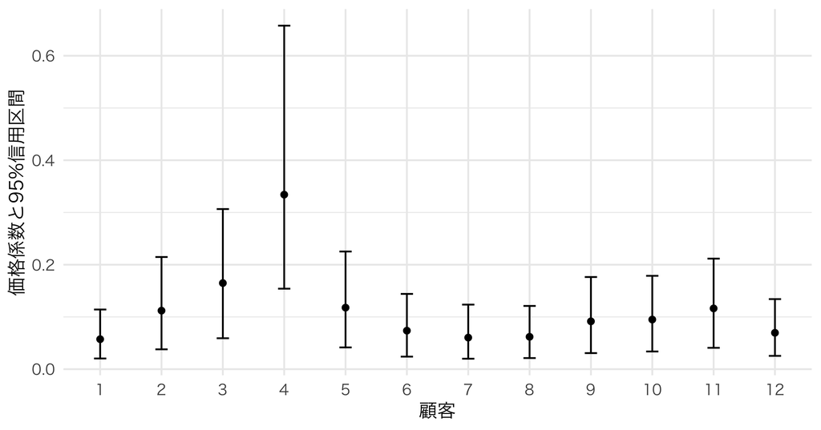

## 計算を診断する

| parameter | split_Rhat |
| --- | --- |
| mu | 1.003 |
| tau | 1.007 |

1に近いことは望ましいが、証明ではない。時系列、探索速度、事前感度も見る。

## 予測は確率を平均する

$$\Pr(y_i^{new}=j\mid D)\approx\frac1B\sum_bP_{ij}^{new}(\theta_i^{(b)})$$

- 各抽出値から選択確率を計算する。
- その後で平均する。
- 事後平均の係数を1回代入する計算とは違う。

## 未使用の回答で比較する

| method | log_loss |
| --- | --- |
| complete | 1.0277 |
| no pooling | 1.0338 |
| HB | 0.9860 |

この比較では、3方法とも同じ属性係数を固定している。個別MLEには計算上の範囲制限がある。

## 既存顧客と新規顧客

| 対象 | 積分する分布 |
| --- | --- |
| 既存 | 本人の係数の事後分布 |
| 新規 | 母集団パラメータの事後＋新しい個人の分布 |

新規顧客を、根拠なく特定のタイプへ分類しない。

## 個人推定と個人識別は違う

個人の履歴が固定されたまま全体人数が増えても、その人の係数が完全に分かるとは限らない。

母集団の推定、個人の区間、予測精度を分けて評価する。

## 次回：予測から施策へ

購入しやすい人に配ればよい、とは限らない。

- 値引きなしでも買う人には、割引が利益の減少になる。
- 値引きによる需要増と、1個あたり利益の低下を比べる。
- 事後分布で期待増分利益を計算し、配布方針をRCTで検証する。

出典と実証例は 講義ノート を参照。